# Examine Prosper in R

# Examine and Summarize Data Using R - Prosper

**By: Saurabh Hinduja**

## Introduction

This section contains information about the dataset selected, reasons why the dataset was selected

*Dataset Selected:* Propser

**What is Propser**

There are many peer to peer networks, like file sharing, meeting new friends and many more. Prosper is America’s first and leading peer-to-peer lending network. In this kind of network, lenders research borrowers and lend them money directly.

Prosper works because it has lower rate of interest than banks and multiple lenders can contribute to the same borrower. Therefore, it is lucrative for borrowers because it has lower rate of interest and lenders like it cause it reduces their risk and can contribute towards a bigger loan amount.

**Why Prosper dataset**

I have used a lot of peer-to-peer networks, usually for file sharing or for meeting new people. When I saw Prosper on the Udacity website, I was intrigued on how peer-to-peer network can be used for financial transactions (mainly borrowing/lending money). I wanted tofind out how Prosper authenticates borrowers and keeps track of all the transactions. A few questions I had were: What is the repayment rate? Is there any failure to return? What factors which affect the credibility of the borrower? Factors which influenced default?

## Dataset Overview

This dataset is part of [Udacity data set options] (https://docs.google.com/document/d/1qEcwltBMlRYZT-l699-71TzInWfk4W9q5rTCSvDVMpc/pub?embedded=true) for the assignment in R which is part of their Data Analysis Nanodegree.

This data set contains 113,937 loans with 81 variables on each loan, including loan amount, borrower rate (or interest rate), current loan status, borrower income, borrower employment status, borrower credit history, and the latest payment information.

### Steps for Data analysis

Below are the steps which will be followed for analysing the Prosper dataset:

1. Data Overview
2. Analysis
3. Final plots and summary

An indepth description of the variabls are available from [Udacity](https://docs.google.com/spreadsheets/d/1gDyi_L4UvIrLTEC6Wri5nbaMmkGmLQBk-Yx3z0XDEtI/edit). After spending considerable amount of time studying the variables, 20 variables were selected for further analysis.

### Variable of interest

The following are the features of interest for this data analysis:

**1. Term** Length of the loan expressed in months

**2. LoanStatus** The current status of the loan: Cancelled, Chargedoff, Completed, Current, Defaulted, FinalPaymentInProgress, PastDue. The PastDue status will be accompanied by a delinquency bucket.

**3. BorrowerState** The two letter abbreviation of the state of the address of the borrower at the time the Listing was created.

**4. ListingCategory** The category of the listing that the borrower selected when posting their listing: 0 - Not Available, 1 - Debt Consolidation, 2 - Home Improvement, 3 - Business, 4 - Personal Loan, 5 - Student Use, 6 - Auto, 7- Other, 8 - Baby&Adoption, 9 - Boat, 10 - Cosmetic Procedure, 11 - Engagement Ring, 12 - Green Loans, 13 - Household Expenses, 14 - Large Purchases, 15 - Medical/Dental, 16 - Motorcycle, 17 - RV, 18 - Taxes, 19 - Vacation, 20 - Wedding Loans

**5. CreditScoreRangeLower** The lower value representing the range of the borrower’s credit score as provided by a consumer credit rating agency.

**6. CreditScoreRangeUpper** The upper value representing the range of the borrower’s credit score as provided by a consumer credit rating agency.

**7. BankcardUtilization** The percentage of available revolving credit that is utilized at the time the credit profile was pulled.

**8. IncomeRange** The income range of the borrower at the time the listing was created.

**9. LoanOriginalAmount** The origination amount of the loan.

**10. Investors** The number of investors that funded the loan.

**11. ListingCreationDate** The date the listing was created.

**12. Occupation** The Occupation selected by the Borrower at the time they created the listing.

**13. IsBorrowerHomeowner** A Borrower will be classified as a homowner if they have a mortgage on their credit profile or provide documentation confirming they are a homeowner.

**14. BorrowerAPR** The Borrower’s Annual Percentage Rate (APR) for the loan.

**15. BorrowerRate** The Borrower’s interest rate for this loan.

**16. Recommendations** Number of recommendations the borrower had at the time the listing was created.

**17. TotalProsperLoans** Number of Prosper loans the borrower at the time they created this listing. This value will be null if the borrower had no prior loans.

**18. DebtToIncomeRatio** The debt to income ratio of the borrower at the time the credit profile was pulled. This value is Null if the debt to income ratio is not available. This value is capped at 10.01 (any debt to income ratio larger than 1000% will be returned as 1001%).

**19. StatedMonthlyIncome** The monthly income the borrower stated at the time the listing was created.

**20. EmploymentStatus** The employment status of the borrower at the time they posted the listing.

There were more varaibles of interest, but they were not consistent (For example: CreditGrade was availale only pre-2009)

```r
library(ggplot2)
library(dplyr)
library(maps)
library(mapproj)
library(gridExtra)
library(GGally)
prosper_data <- read.csv("prosperLoanData.csv")
```

## Exploratory Data Analysis

Exploratory data analysis is divided into 3 sections, depending on number of data variables taken for analysis. (Univariable, Bivariate and Multivariate)

The first step for exploratory data analysis is to check verify that the dataset has 81 variable and 113,937 variable. Also, we will be subsetting the dataset and forming a new dataset which will just have the variables for our interest.

Verify the dimensions

```r
dim(prosper_data)
```

```
[1] 113937     81
```

After verification that the dataset is complete, we will now subset the dataset

```r
# First we create a list of variables to subset
VarstoSubset <- c("Term","LoanStatus","BorrowerState","ListingCategory..numeric.",
               "CreditScoreRangeLower","CreditScoreRangeUpper",
               "BankcardUtilization","IncomeRange", "TotalProsperLoans",
               "LoanOriginalAmount", "Investors","ListingCreationDate",
               "Occupation","IsBorrowerHomeowner","BorrowerAPR","BorrowerRate",
               "Recommendations","DebtToIncomeRatio", "StatedMonthlyIncome",
               "EmploymentStatus")
## Now we create the data subset
prosperSubSet <- subset(prosper_data, select = VarstoSubset)
## Check the completeess of the data
dim(prosperSubSet)
```

```
[1] 113937     20
```

```r
## Check the Variables and their data types
str(prosperSubSet)
```

```
'data.frame':   113937 obs. of  20 variables:
 $ Term                     : int  36 36 36 36 36 60 36 36 36 36 ...
 $ LoanStatus               : Factor w/ 12 levels "Cancelled","Chargedoff",..: 3 4 3 4 4 4 4 4 4 4 ...
 $ BorrowerState            : Factor w/ 52 levels "","AK","AL","AR",..: 7 7 12 12 25 34 18 6 16 16 ...
 $ ListingCategory..numeric.: int  0 2 0 16 2 1 1 2 7 7 ...
 $ CreditScoreRangeLower    : int  640 680 480 800 680 740 680 700 820 820 ...
 $ CreditScoreRangeUpper    : int  659 699 499 819 699 759 699 719 839 839 ...
 $ BankcardUtilization      : num  0 0.21 NA 0.04 0.81 0.39 0.72 0.13 0.11 0.11 ...
 $ IncomeRange              : Factor w/ 8 levels "$0","$1-24,999",..: 4 5 7 4 3 3 4 4 4 4 ...
 $ TotalProsperLoans        : int  NA NA NA NA 1 NA NA NA NA NA ...
 $ LoanOriginalAmount       : int  9425 10000 3001 10000 15000 15000 3000 10000 10000 10000 ...
 $ Investors                : int  258 1 41 158 20 1 1 1 1 1 ...
 $ ListingCreationDate      : Factor w/ 113064 levels "2005-11-09 20:44:28.847000000",..: 14184 111894 6429 64760 85967 100310 72556 74019 97834 97834 ...
 $ Occupation               : Factor w/ 68 levels "","Accountant/CPA",..: 37 43 37 52 21 43 50 29 24 24 ...
 $ IsBorrowerHomeowner      : Factor w/ 2 levels "False","True": 2 1 1 2 2 2 1 1 2 2 ...
 $ BorrowerAPR              : num  0.165 0.12 0.283 0.125 0.246 ...
 $ BorrowerRate             : num  0.158 0.092 0.275 0.0974 0.2085 ...
 $ Recommendations          : int  0 0 0 0 0 0 0 0 0 0 ...
 $ DebtToIncomeRatio        : num  0.17 0.18 0.06 0.15 0.26 0.36 0.27 0.24 0.25 0.25 ...
 $ StatedMonthlyIncome      : num  3083 6125 2083 2875 9583 ...
 $ EmploymentStatus         : Factor w/ 9 levels "","Employed",..: 9 2 4 2 2 2 2 2 2 2 ...
```

We verified that the subset has 113937 rows and 20 variables alpng with their data types.

## Creating new data variables

Before we continue with our data analysis we need to define who is a borrower in default. The propser dataset has done a very good job in catagorizing the dataset, but if dig into the definations of “Chargedoff” and “Defaulted” we find that their are still a few more rows which should fall into defaulted (For example: people who Past Due(>61 days) )

**Borrowers in Default**

Creating a new variable DefaultBorrowers (1 - Person is in Default, 0 - Not in Default)

```r
prosperSubSet$DefaultBorrowers <- ifelse(
                                        prosperSubSet$LoanStatus == "Defaulted" |
                                        prosperSubSet$LoanStatus == "Chargedoff" |
                                        prosperSubSet$LoanStatus == "Past Due (61-90 days)" |
                                        prosperSubSet$LoanStatus == "Past Due (91-120 days)"|
                                        prosperSubSet$LoanStatus == "Past Due (>120 days)",

                                        1,0)
str(prosperSubSet)
```

```
'data.frame':   113937 obs. of  21 variables:
 $ Term                     : int  36 36 36 36 36 60 36 36 36 36 ...
 $ LoanStatus               : Factor w/ 12 levels "Cancelled","Chargedoff",..: 3 4 3 4 4 4 4 4 4 4 ...
 $ BorrowerState            : Factor w/ 52 levels "","AK","AL","AR",..: 7 7 12 12 25 34 18 6 16 16 ...
 $ ListingCategory..numeric.: int  0 2 0 16 2 1 1 2 7 7 ...
 $ CreditScoreRangeLower    : int  640 680 480 800 680 740 680 700 820 820 ...
 $ CreditScoreRangeUpper    : int  659 699 499 819 699 759 699 719 839 839 ...
 $ BankcardUtilization      : num  0 0.21 NA 0.04 0.81 0.39 0.72 0.13 0.11 0.11 ...
 $ IncomeRange              : Factor w/ 8 levels "$0","$1-24,999",..: 4 5 7 4 3 3 4 4 4 4 ...
 $ TotalProsperLoans        : int  NA NA NA NA 1 NA NA NA NA NA ...
 $ LoanOriginalAmount       : int  9425 10000 3001 10000 15000 15000 3000 10000 10000 10000 ...
 $ Investors                : int  258 1 41 158 20 1 1 1 1 1 ...
 $ ListingCreationDate      : Factor w/ 113064 levels "2005-11-09 20:44:28.847000000",..: 14184 111894 6429 64760 85967 100310 72556 74019 97834 97834 ...
 $ Occupation               : Factor w/ 68 levels "","Accountant/CPA",..: 37 43 37 52 21 43 50 29 24 24 ...
 $ IsBorrowerHomeowner      : Factor w/ 2 levels "False","True": 2 1 1 2 2 2 1 1 2 2 ...
 $ BorrowerAPR              : num  0.165 0.12 0.283 0.125 0.246 ...
 $ BorrowerRate             : num  0.158 0.092 0.275 0.0974 0.2085 ...
 $ Recommendations          : int  0 0 0 0 0 0 0 0 0 0 ...
 $ DebtToIncomeRatio        : num  0.17 0.18 0.06 0.15 0.26 0.36 0.27 0.24 0.25 0.25 ...
 $ StatedMonthlyIncome      : num  3083 6125 2083 2875 9583 ...
 $ EmploymentStatus         : Factor w/ 9 levels "","Employed",..: 9 2 4 2 2 2 2 2 2 2 ...
 $ DefaultBorrowers         : num  0 0 0 0 0 0 0 0 0 0 ...
```

### Univariate Data Analysis

The first thing we will see that if there there were some economic crisis which caused the an increase in loan defaults.

```r
# Year in which loan was taken
prosperSubSet$LoanTakenYear <- format (
                                  as.Date(prosperSubSet$ListingCreationDate), "%Y"
)
```

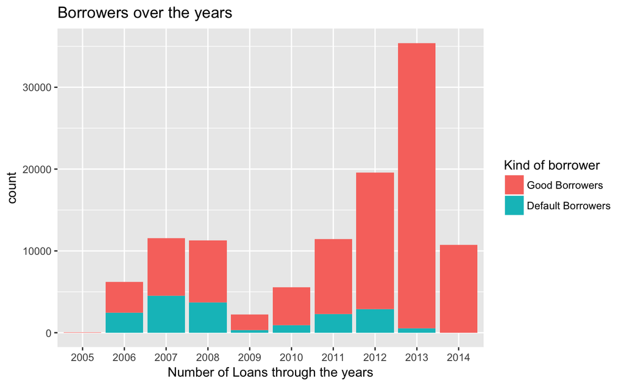

```r
# Plot the new variable
ggplot(prosperSubSet, aes(prosperSubSet$LoanTakenYear, fill = factor(DefaultBorrowers))) + geom_bar() + scale_fill_discrete( "Kind of borrower", labels = c ("Good Borrowers", "Default Borrowers")) + ggtitle("Borrowers over the years") + labs(x = "Number of Loans through the years")
```

There are few important things to note here:

1. The ratio of defaulters was high in 2007,2008
2. There was a sudden dip in number of loans taken in 2009. After a bit of research we can see that there was an economic depression in 2009.
3. There was a exponential increase number of loans taken fron 2009 to 2013.
4. There was a dip again in 2014. Again, a bit of searching showed that there was an economic slowdown in 2014
5. There was a a linear increase in number of defualters from 2009 to 2012

It should be kept in mind that the above figures are only on new loans taken in that year. It does not include the on-going loans during that period.

**Loan Term and Loan Status**

Now we should look into continuing loans. The status of the loan and its status.

For this we will break down terms into 4 terms.

1. Start - 0 months
2. 1 year - 12 months
3. 3 years - 36 months
4. 5 years - 60 months

```r
# Check summary of loan terms
summary(prosperSubSet$Term)
```

```
   Min. 1st Qu.  Median    Mean 3rd Qu.    Max.
  12.00   36.00   36.00   40.83   36.00   60.00
```

```r
#Check summary of default borrowers
summary(prosperSubSet$DefaultBorrowers)
```

```
   Min. 1st Qu.  Median    Mean 3rd Qu.    Max.
 0.0000  0.0000  0.0000  0.1548  0.0000  1.0000
```

```r
#Check summary of Loan status
summary(prosperSubSet$LoanStatus)
```

```
             Cancelled             Chargedoff              Completed                Current
                     5                  11992                  38074                  56576
             Defaulted FinalPaymentInProgress   Past Due (>120 days)   Past Due (1-15 days)
                  5018                    205                     16                    806
 Past Due (16-30 days)  Past Due (31-60 days)  Past Due (61-90 days) Past Due (91-120 days)
                   265                    363                    313                    304
```

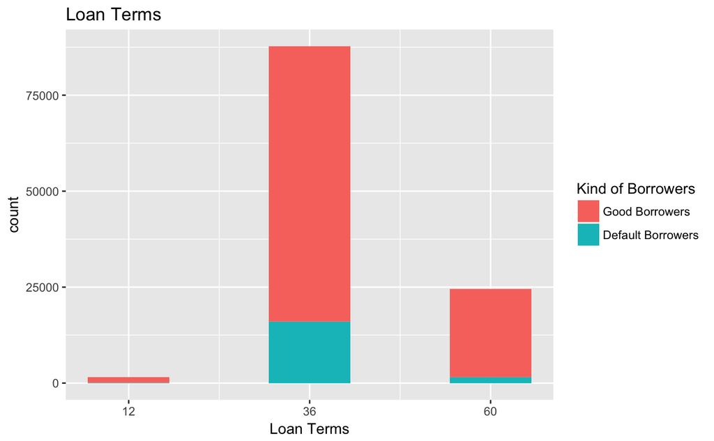

```r
#Create graphs
ggplot(prosperSubSet, aes(Term, fill = factor(DefaultBorrowers))) +geom_bar() + scale_x_continuous(breaks = c(0,12,36,60)) + scale_fill_discrete("Kind of Borrowers", labels = c("Good Borrowers", "Default Borrowers")) + ggtitle("Loan Terms") + labs(x = "Loan Terms")
```

From the summary we can observe the following: 1. Median length of loan is 36 months 2. 15% of the borrowers are in default

**Loan amount and investors**

Now let us check the details on the original loan amount and investors interested in giving loans.

```r
#Check summary for laoan amount
summary(prosperSubSet$LoanOriginalAmount)
```

```
   Min. 1st Qu.  Median    Mean 3rd Qu.    Max.
   1000    4000    6500    8337   12000   35000
```

```r
#Check summary for average investors
summary(prosperSubSet$Investors)
```

```
   Min. 1st Qu.  Median    Mean 3rd Qu.    Max.
   1.00    2.00   44.00   80.48  115.00 1189.00
```

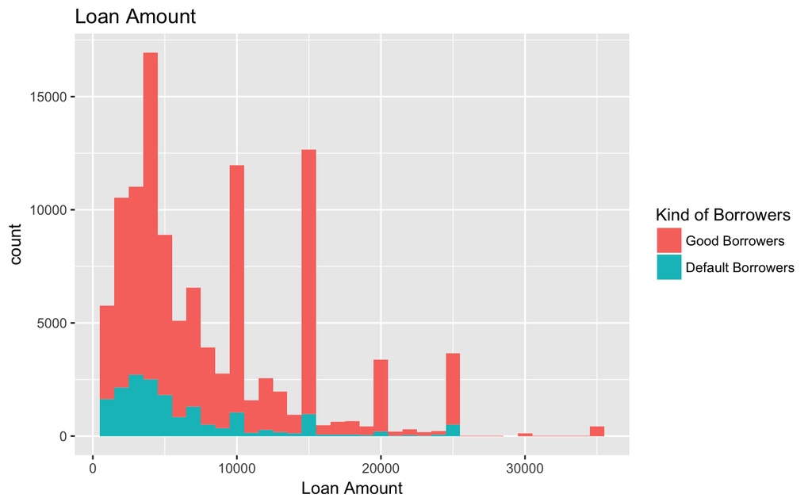

```r
#Plot loan ammount
loanterm <- ggplot(prosperSubSet, aes(LoanOriginalAmount, fill = factor(DefaultBorrowers))) +
  scale_fill_discrete("Kind of Borrowers", labels = c ("Good Borrowers", "Default Borrowers")) +
  ggtitle("Loan Amount") + labs(x = "Loan Amount")

loanterm + geom_histogram(binwidth = 1000)
```

From the above information it can be noted that: 1. The median loan amount is $6,500. Average loan amount is $8,337. The loan range is $1000 to $35,000 with a third quantile at $12,000. 2. Median number of investors for the loan are 44, with third quantile on 115 and maximum number of investors being $1189, this could be an outlier. 3. The graph for borrowers (good and default) is right skewed. 4. The high number of borrowers at $10,000 , $15,000, $20,000, $25,000 pull the average to be higher than median

Now, let us look deeper into the graph and try to eliminate some outliers by examining just 95% of the data.

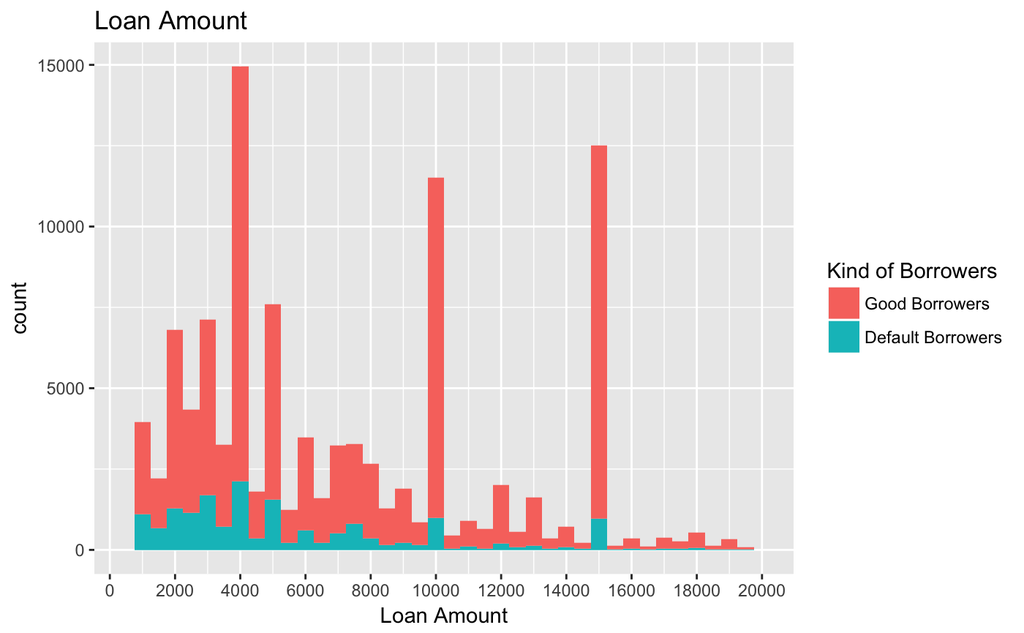

```r
loanterm +
  geom_histogram(binwidth = 500)  + scale_x_continuous( limits = c (500, quantile(prosperSubSet$LoanOriginalAmount, 0.95)),
                      breaks = c(0,2000,4000,6000,8000,10000,12000,14000,16000,18000,20000))
```

We can see that below the mean, that is, $8,337 people request in the all kinds of amounts in the range. But, above $8,337 people request in “whole” values, of $10,000 and $15,000.

**Income Range**

Analyzing the income range of borrowers.

```r
#Summary of Income range
summary(prosperSubSet$IncomeRange)
```

```
            $0      $1-24,999      $100,000+ $25,000-49,999 $50,000-74,999 $75,000-99,999  Not displayed
           621           7274          17337          32192          31050          16916           7741
  Not employed
           806
```

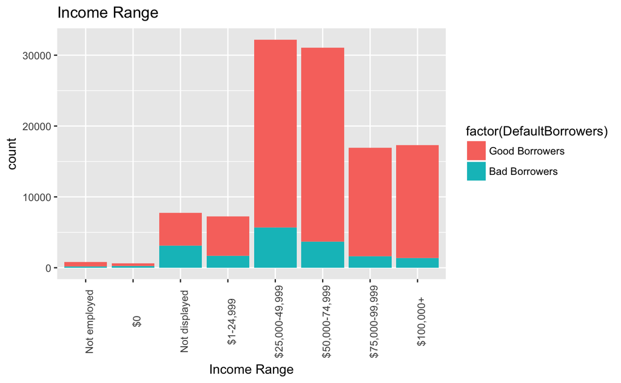

```r
#Ploting the income range
plotincomerange <- ggplot(prosperSubSet, aes(IncomeRange, fill = factor(DefaultBorrowers))) +
  scale_x_discrete(limits = c ("Not employed", "$0", "Not displayed",
                "$1-24,999", "$25,000-49,999", "$50,000-74,999",
                "$75,000-99,999", "$100,000+")) +
  geom_bar() +
  scale_fill_discrete(labels = c("Good Borrowers", "Bad Borrowers")) +
  ggtitle("Income Range") + labs(x = "Income Range") +
   theme(axis.text.x = element_text(angle = 90))
plotincomerange
```

```r
NA
```

**Borrowers State**

Now, we plot the state in which the borrowers live. This is done to check if there is a pattern in place where bad borrowers live.

```r
#Summary of borrowers across the states
summary(prosperSubSet$BorrowerState)
```

```
         AK    AL    AR    AZ    CA    CO    CT    DC    DE    FL    GA    HI    IA    ID    IL    IN    KS
 5515   200  1679   855  1901 14717  2210  1627   382   300  6720  5008   409   186   599  5921  2078  1062
   KY    LA    MA    MD    ME    MI    MN    MO    MS    MT    NC    ND    NE    NH    NJ    NM    NV    NY
  983   954  2242  2821   101  3593  2318  2615   787   330  3084    52   674   551  3097   472  1090  6729
   OH    OK    OR    PA    RI    SC    SD    TN    TX    UT    VA    VT    WA    WI    WV    WY
 4197   971  1817  2972   435  1122   189  1737  6842   877  3278   207  3048  1842   391   150
```

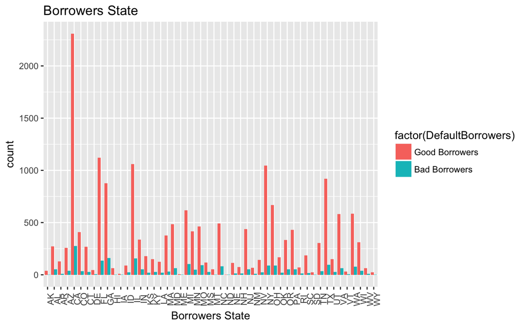

```r
#Inital graph of borrowers
initialstateplot <- ggplot(na.omit(prosperSubSet), aes(BorrowerState, fill = factor(DefaultBorrowers))) +
  geom_bar(position = "dodge") +
    scale_fill_discrete(labels = c("Good Borrowers", "Bad Borrowers")) +
  ggtitle("Borrowers State") + labs(x = "Borrowers State") +
   theme(axis.text.x = element_text(angle = 90))
initialstateplot
```

```r
#Mapping States to a map
prosperSubSet$BorrowerStateFullName <- tolower(state.name
                                               [match(prosperSubSet$BorrowerState, state.abb)])
usmap <- map_data("state")
usstates <- data.frame(state.center, state.abb)
#Mapping bad borrowers in each  state
bad_borrow_state <- prosperSubSet %>%
  group_by(BorrowerStateFullName, BorrowerState, DefaultBorrowers) %>%
  summarise(count = n()) %>%
  filter(DefaultBorrowers == 1)
DefaultMap <- ggplot() +
  geom_map(data = usmap, map =usmap, aes(x = long, y = lat, map_id = region, label = region))+
  geom_map(data = na.omit(bad_borrow_state), map=usmap, aes(fill = count, map_id = BorrowerStateFullName)) +
  geom_text(data = usstates, aes(x = x, y = y, label = state.abb, group = NULL)) +
  scale_fill_continuous(low ='blue', high='red', guide = 'colorbar')+
  labs(x = "Bad Borrowers", y=NULL) +
  coord_map("albers", lat0= 39, lat1 = 45)
```

```
Ignoring unknown aesthetics: x, y, label
```

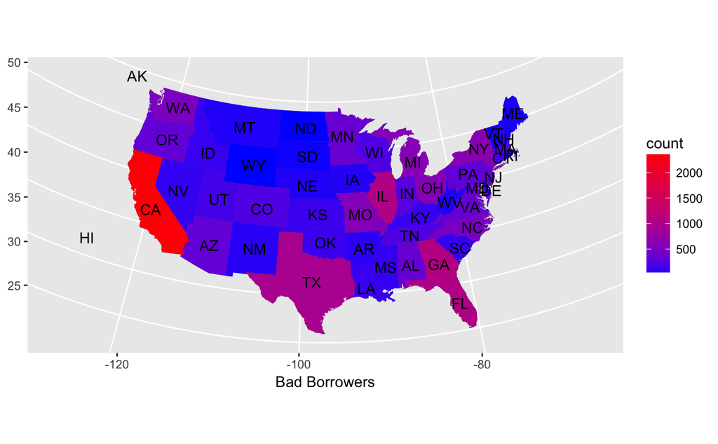

```r
DefaultMap
```

From the map it can be seen: 1. California stands out, that means it has the highest number of Bad borrowers, but this can also be due to the fact that California also has the highest number of total borrowers 2. Other Sates which stand out are Texas, Illonois, Florida and Georgia. 3. Texas, Florida and Illonois also have high number of borrower nearly 6000 4. Georgia has high number of borrowers and lower number of total borrowers. 5. Central America has lowest number of borrower and bad borrowers. Reasons for this may be lower cost of living, low population. 6. North Dakota and Wyoming have least number of borrowers

**Listing Catagory** s Analyzing the purpose for which the loan was taken out.

```r
#Create a variable for Listing catagory
ListCat <- c("Not Available", "Debt Consolidation", "Home Improvement",
                      "Business", "Personal Loan", "Student Use", "Auto", "Other",
                      "Baby&Adoption", "Boat", "Cosmetic Procedure",
                      "Engagement Ring", "Green Loans","Household Expenses",
                      "Large Purchases", "Medical/Dental", "Motorcycle",
                      "RV", "Taxes", "Vacation", "Wedding Loans")
#Mapping the new variable
prosperSubSet$ListingCategoryName <- ListCat[(prosperSubSet$ListingCategory..numeric.)+1]
# Creating Summary
summary(prosperSubSet$ListingCategory..numeric)
```

```
   Min. 1st Qu.  Median    Mean 3rd Qu.    Max.
  0.000   1.000   1.000   2.774   3.000  20.000
```

[figure not shown]

```r
#Plotting the Listing Category
ListCatGraph <- ggplot(prosperSubSet, aes(prosperSubSet$ListingCategoryName, fill = factor(DefaultBorrowers))) +
    geom_bar() +
  scale_fill_discrete("Borrowers", labels = c("Good Borrowers", "Bad Borrowers")) +
  ggtitle("Income Range") + labs(x = "Income Range") +
  theme(axis.text.x = element_text(angle = 90))
# Debit Consolidation overshadoewed other values due to which can't observe anything adding log
ListCatGraph + scale_y_log10()
```

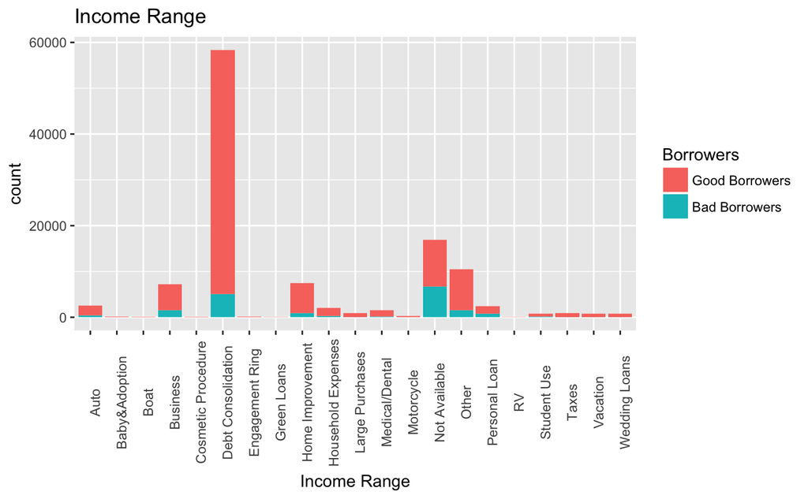

```r
ListCatGraph
```

### Bivariate Analysis

Now to look at default borrowers let us dive into bivariate analysis

**Debt to Income Ratio and Stated Income**

Let us look at the debt to income trtio of borrowers across the prosper dataset. We are interested in knowing if people wiht high income take higher loans or other way round and what are case of them being in default. FOr this we will make a scatter plot and consider only perople with income less than $25k

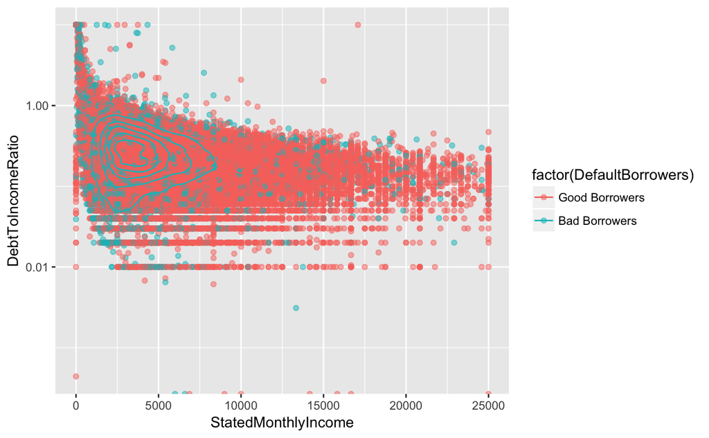

```r
ggplot(prosperSubSet, aes(StatedMonthlyIncome,
                         DebtToIncomeRatio,
                         colour = factor(DefaultBorrowers))) +
  geom_point(alpha = 0.5) +
  scale_x_continuous(limits = c(0,25000)) +
  #scale_y_continuous(limits = c(0,1)) +
  scale_y_log10() +
  scale_color_discrete(labels = c("Good Borrowers", "Bad Borrowers")) +
  geom_density2d()
```

The log scale displays some interesting characteristics: 1. Most have debt-to-income ratio greater than 0.01 2. There are some outliers with debt-to-income ratio of 0 3. The contour lines (rings) show a high concentration of bad borrowers. 4. Changing the y limitds show us that a lot of the borrowers have an income of zero and are on Y axis all the way to 10. 5.It suggests a negative correlation between income and debt

**Debt to Income and Interest Rate**

Let us see what relationship does Debt-to-interest have with Interest rate

```
Ignoring unknown parameters: alpaha
```

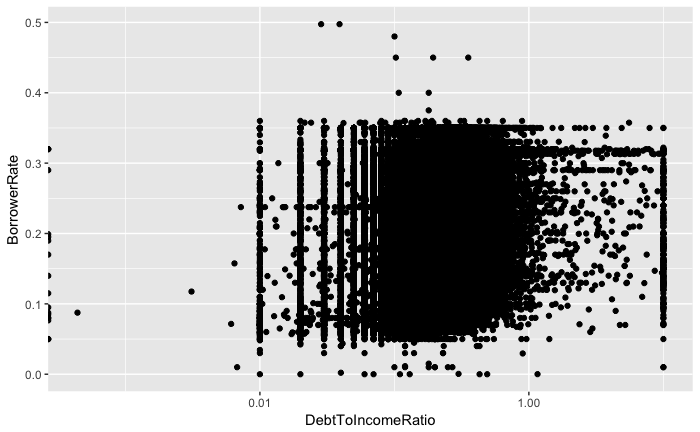

```r
ggplot(prosperSubSet, aes( DebtToIncomeRatio, BorrowerRate)) +
  geom_point(alpaha =0.1) + scale_x_log10()
```

Points to be noted 1. Positive correlation between Borrower rate and Debt-to-income ratio

**Listing Category and Loan Amount**

Creating a few box blots ti examine the loan category, loan amount and borrowing rate.

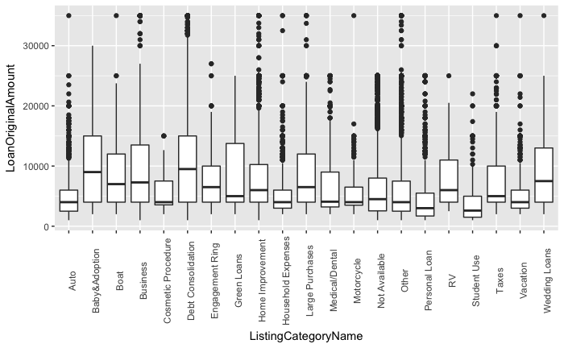

```r
ggplot(prosperSubSet, aes(ListingCategoryName,
                         LoanOriginalAmount,
                         group = ListingCategoryName)) +
  geom_boxplot() +
  theme(axis.text.x = element_text(angle = 90))
```

```r
NA
```

From the above graph it can be noted that: 1. Debt consolidation and Baby Adoption have the highest loan amount 2. Lowest loan amounts are for Auto, Household expenses, Motorcycle, Personal loan and Student use.

**Loan Category and Borrower Rate**

Box plot for Loan Category and Borrower rate

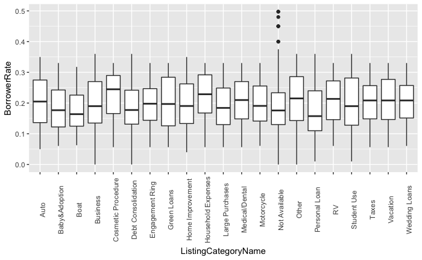

```r
ggplot(prosperSubSet, aes(ListingCategoryName, BorrowerRate, group = ListingCategoryName))+
  geom_boxplot()+
  theme(axis.text.x = element_text(angle = 90))
```

Average borrowing rate is between 0.15 and 0.25 acroess all categories

**Loan Term and Loan Amount**

Box plot between Loan term and loan amount.

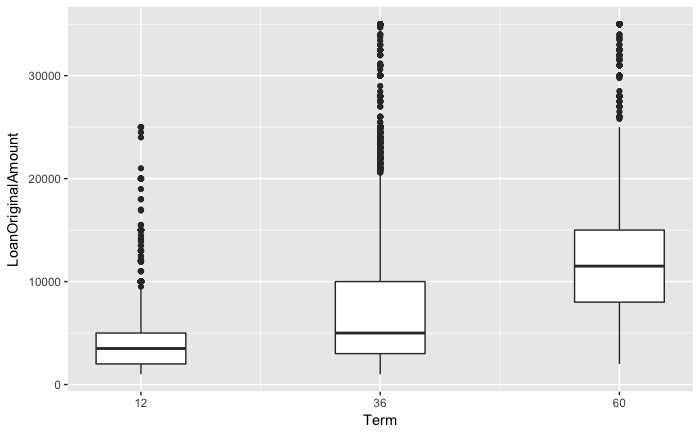

```r
ggplot(prosperSubSet, aes(Term, LoanOriginalAmount, group = Term))+
  geom_boxplot() +
  scale_x_continuous(breaks = c(0,12,36,60))
```

Points to note: 1. The average loan amount for 12 months term is lowest followed by 36 and 60. This is expected as it takes longer to return a bigger loan amount.

**Loan Amount and Bankcard Utilization**

Let us see how do people utalize their bankcard

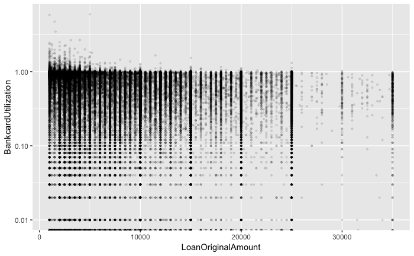

```r
ggplot(prosperSubSet, aes(LoanOriginalAmount, BankcardUtilization))+
  geom_point(alpha=0.1, size=0.75,position = "jitter")+
  scale_y_log10()
```

Things to note: 1. Card utilization is higher for people taking out a lower loan 2. Spikes in plot at 10K, 15K, 20K, 25K 35K . People might be taking loand of this amount more

**Loan Amount and Investore**

Let us analyse if there is relation between Loan Amount and Investors

```
Ignoring unknown parameters: alpah
```

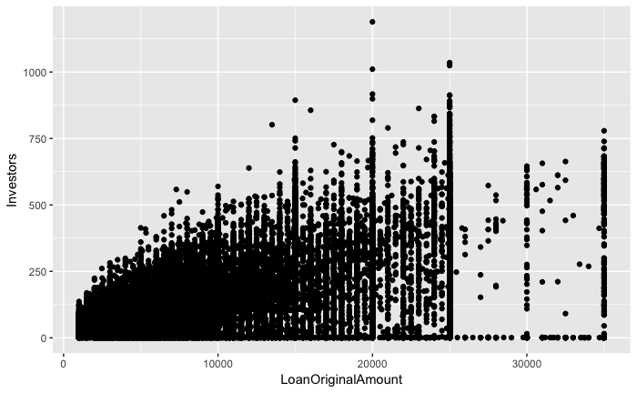

```r
ggplot(prosperSubSet, aes(LoanOriginalAmount, Investors)) +
  geom_point(alpah =0.2, position ="jitter")
```

1. This shoows a positive relationship between the amount and number of investors
2. Number of investors drop when amount increased from 25K

### Multivariate Analysis

Now let us do some multivariate analysis to see how they affect each other and to rule out any correlations which might look like causation.

To perform multivariate analysis we have to first calculate the pearson correlations.

**Pearsons Correlations**

```r
ggcorr(prosperSubSet, label = TRUE, label_size = 2, hjust = 0.8, size = 2.5, angle =-10)
```

[output not shown]

**Credit Score, Loan Amount, Type of Borrower**

Let us see if we can find some correlation on these 3 variables.

```r
CLG1 <- ggplot(subset(prosperSubSet, DefaultBorrowers == 1), aes(CreditScoreRangeUpper, LoanOriginalAmount)) +
  geom_point(alpha = 0.2, color = "red")+
  ggtitle("Bad Borrowers")

CLG2 <- ggplot(subset(prosperSubSet, DefaultBorrowers == 0), aes(CreditScoreRangeUpper, LoanOriginalAmount)) +
  geom_point(alpha = 0.2, color = "green")+
  ggtitle("Good Borrowers")

grid.arrange(CLG1, CLG2, nrow=1)
```

[output not shown]

**Loan Amount, Year and Income Range**

Let us see if there is any difference in Loan amount taken by an income group over the years. This can show if there is any effect of inflation.

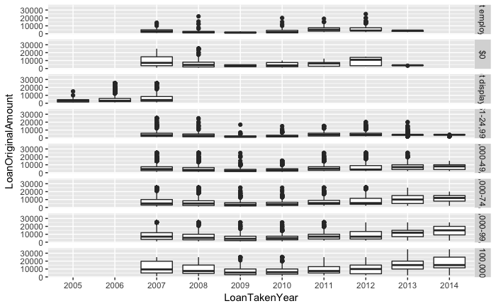

```r
positions <-  c ("Not employed", "$0", "Not displayed",
                "$1-24,999", "$25,000-49,999", "$50,000-74,999",
                "$75,000-99,999", "$100,000+")
prosperSubSet <- transform(prosperSubSet,
               IncomeRange = factor(IncomeRange,
                                    levels = positions,
                                    labels = positions))
ggplot(prosperSubSet, aes(LoanTakenYear, LoanOriginalAmount)) + geom_boxplot()+
         facet_grid(IncomeRange ~ .)
```

Interesting observations 1. Average Loan amount take has increased over the years across the income groups. This might be due to inflation 2. Dip in loan about across all income 2009-2010. 3. Higher the income group higher the average loan amount 4. Higher the income group more variance in the loan amount.

**Loan Year, Loan Amount, Type of Borrower**

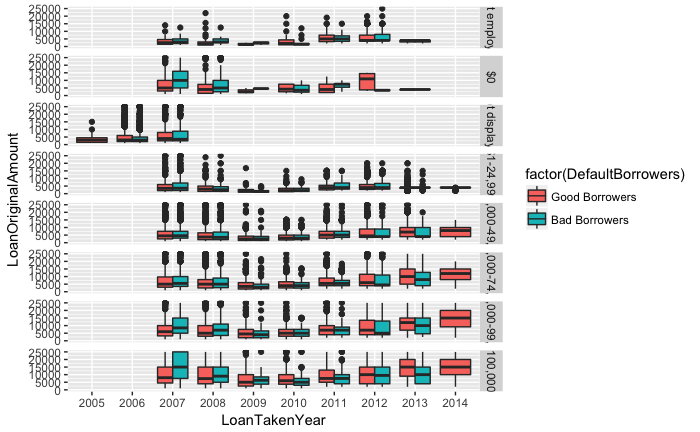

```r
ggplot(prosperSubSet, aes(LoanTakenYear, LoanOriginalAmount, fill = factor(DefaultBorrowers))) +
  geom_boxplot() +
  facet_grid(IncomeRange ~ .)+
  scale_y_continuous(limits = c(0,25000))+
  scale_fill_discrete(breaks = c(0,1), labels = c("Good Borrowers", "Bad Borrowers"))
```

Observations 1. Higgher average loan amount take by bad borrowers till 2010 2. Lower average loan amount by bad borrowers post 2010 3. No bad borrowes in 2014 (incomplete data??)